# Mass Collaboration

MACS 30000 University of Chicago

November 8, 2017

## Open-source software development

- [Republican Plan Would Raise Taxes on Millions](https://www.nytimes.com/2017/11/06/business/republican-plan-would-raise-taxes-on-millions.html)
- [TaxBrain](https://www.ospc.org/taxbrain/)
- [Open Source Economics](https://github.com/open-source-economics)
- [Contributors to `OG-USA`](https://github.com/open-source-economics/OG-USA/graphs/contributors)

## Open-source software development

- Why it exists
- Why it’s important
- Why to participate

## Version control

- Revisions in research
- Tracking revisions
- Multiple copies
  - `analysis-1.r`
  - `analysis-2.r`
  - `analysis-3.r`
- Cloud storage (e.g. Dropbox, Google Drive, Box)
- Version control software
  - Repository

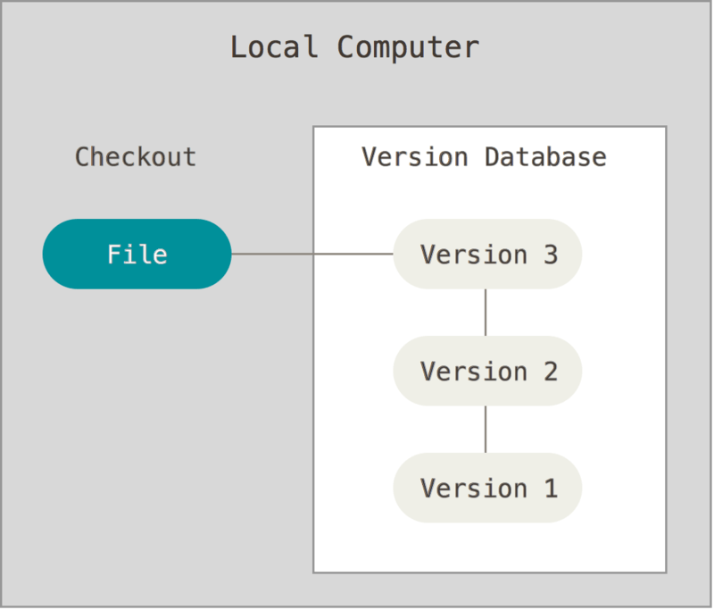

## Git

- Version control software
- Systematically track changes to files
- Sync repositories between local and remote servers
- Collaborative project management

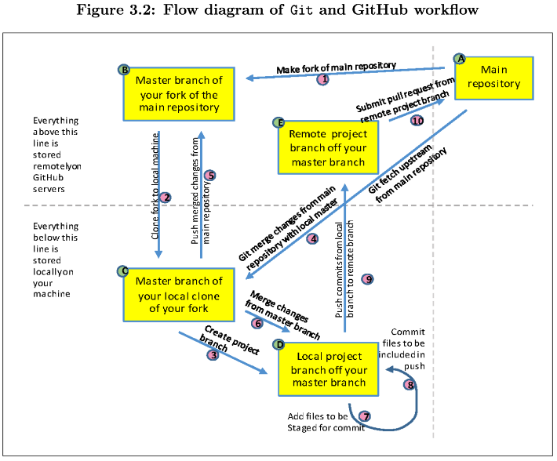

## Long-running branches

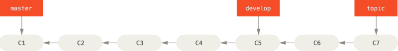

## Topic branches

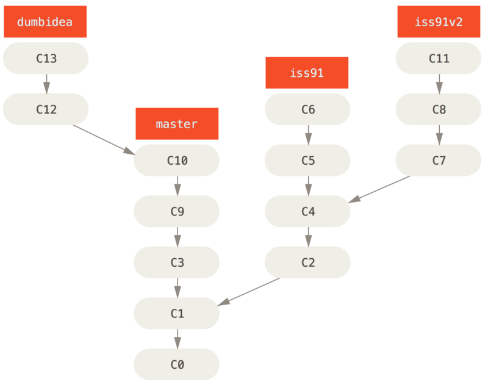

## Topic branches

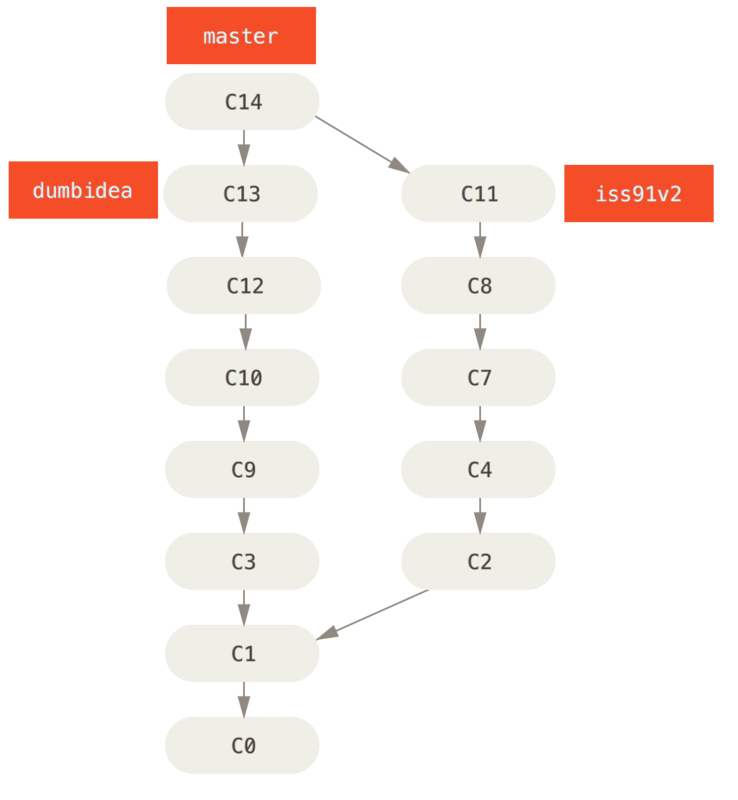

[figure not shown]

## How to participate

[figure not shown]

## Mass collaboration

- Drawing on large-scale human collaboration to conduct research
- Useful when:
  - Computers are dumb
  - Researchers are dumb inside-the-box

## Mass collaboration

1. Human computation
2. Open call
3. Distributed data collection

## Split-apply-combine

- **Split** data into pieces
- **Apply** some function to each piece
- **Combine** the results back together again

## Importance of redundancy

- Rely on the quality of workers
- Redundancy
- Training workers

## How to recruit workers

- Free
- Paid
  - Amazon MTurk

## Galaxy Zoo team

- What worked?

## Open calls

- Pose a problem asking for specific, measurable solutions from other people
- Offer a reward/incentive for participation
- Compare and evaluate the solutions using a consistent and measurable metric

## Netflix prize

- Propose a problem
- Internal research plateaued
- Release an anonymized dataset of 100 million movie ratings to predict 3 million held-out ratings
- Prize criteria

## Strengths and weaknesses of open calls

- What are the benefits to the researchers proposing the problem?
- What are the benefits to the participants proposing the solutions?
- Are there any concerns/harm based on this research design?

## Designing your own mass collaboration

- Motivate participants
- Leverage heterogeneity
- Focus attention
- Be ethical
- What happens if nobody comes?